# CardioGoodFitness_AIML_Project_01

### Steven Gilbert Archuleta

### Cardio Good Fitness (AIML Project 01)

Due: 18JUN2021 19:30 local time,

Sacramento, California (PDT)

[My GitHub Link for Project 1](https://github.com/GL-AIML-International/gl-pgp-aiml-ba-uta-intl-may21-stevearchuleta)

### Objective:

Explore the dataset and practice extracting basic observations about the data.

### Do the following :

1. Come up with a customer profile (characteristics of a customer) for the different products.
2. Perform uni-variate and multi-variate analyses.
3. Generate a set of insights and recommendations that will help the company target new customers.

### Context:

This dataset represents customers of a retail store called Cardio Good Fitness which sells treadmill products. It contains the following variables:

### Attributes/Series/Features:

1. Product - the model number of the treadmill (TM195, TM498, TM798)
2. Age - of customer (in number of years)
3. Gender - of the customer
4. Education - of the customer (in number of years)
5. Marital Status - of the customer
6. Usage - average number of times the customer intends to use the treadmill each week
7. Fitness - self-rated fitness score of the customer (5 - very fit, 1 - poorly fit)
8. Income - of the customer
9. Miles - expected to run on the treadmill each week

### 1. Import libraries and packages

```python
import numpy as np
import pandas as pd
import matplotlib.pyplot as plt
import seaborn as sns
%matplotlib inline
plt.style.use("ggplot")
sns.set_style('darkgrid')
import warnings
warnings.filterwarnings("ignore")
```

### 2. Read the dataset into Jupyter Notebook

```python
df = pd.read_csv('CardioGoodFitness.csv')
```

### Overview of Dataset

1. df Data Type - pandas core frame dataframe
2. Length - number of data objects
3. Shape - (rows, columns) (data objects, attributes)
4. Columns - list of variable attributes
5. List Comprehension - column-based indexing integers for iloc() function
6. Dictionary Comprehension - column-based key-value pairs
7. Data Types - value count of datatypes
8. Info - class, range index, data columns, data types, memory usage
9. Null - sum of missing values
10. Head - first 5 data objects
11. Tail - last 5 data objets
12. Sample(10) - 10 random data objects
13. Describe - five number summary of descriptive statistics

### 3. Return the Pandas datatype for the dataframe named "df"

```python
type(df)
```

```
pandas.core.frame.DataFrame
```

### 4. Return the length of the Pandas dataframe named "df"

```python
len(df)
```

```
180
```

### 5. Return the shape of the Pandas dataframe named "df"

```python
df.shape
```

```
(180, 9)
```

### 6. Return the column label values for the Pandas dataframe named "df"

```python
df.columns
```

```
Index(['Product', 'Age', 'Gender', 'Education', 'MaritalStatus', 'Usage',
       'Fitness', 'Income', 'Miles'],
      dtype='object')
```

### 7. Return a LIST COMPREHENSION that maps an index integer to the column label values for the Pandas dataframe named "df" NOTE: These index numbers may be used in the iloc() function if/when referencing multiple columns

```python
# LIST COMPREHENSION - build a reference list of all columns and their indexes  (identify column name by index)

df_col_mapping_list = [f"{c[0]}:{c[1]}" for c in enumerate(df.columns)]
print(df_col_mapping_list)
```

```
['0:Product', '1:Age', '2:Gender', '3:Education', '4:MaritalStatus', '5:Usage', '6:Fitness', '7:Income', '8:Miles']
```

### 8. Return a DICTIONARY COMPREHENSION that maps a key integer to the column label values for the Pandas dataframe named "df" NOTE: These key numbers may be used to reference/access particular columns

```python
# DICTIONARY COMPREHENSION - build a dictionary view of all columns and their indexes  (tool to rename columns, when needed)
df_col_mapping_dict = {c[0]:c[1] for c in enumerate(df.columns)}
print(df_col_mapping_dict)
```

```
{0: 'Product', 1: 'Age', 2: 'Gender', 3: 'Education', 4: 'MaritalStatus', 5: 'Usage', 6: 'Fitness', 7: 'Income', 8: 'Miles'}
```

### 9. Return the datatypes for each of the column label values for the Pandas dataframe named "df"

```python
df.dtypes.value_counts()
```

```
int64     6
object    3
dtype: int64
```

### 10. Return a table that identifies the following "INFORMATION" about the Pandas dataframe named "df"

#### OBSERVABLE return:

###### 10a: type of data structure,

###### 10b: range of data objects,

###### 10c: number of column label values,

###### 10d: column index number,

###### 10e: column label value,

###### 10f: non-null count,

###### 10g: datatype for each column label value,

###### 10h: count of series datatypes,

###### 10i: memory usage

```python
df.info()
```

```
<class 'pandas.core.frame.DataFrame'>
RangeIndex: 180 entries, 0 to 179
Data columns (total 9 columns):
 #   Column         Non-Null Count  Dtype
---  ------         --------------  -----
 0   Product        180 non-null    object
 1   Age            180 non-null    int64
 2   Gender         180 non-null    object
 3   Education      180 non-null    int64
 4   MaritalStatus  180 non-null    object
 5   Usage          180 non-null    int64
 6   Fitness        180 non-null    int64
 7   Income         180 non-null    int64
 8   Miles          180 non-null    int64
dtypes: int64(6), object(3)
memory usage: 12.8+ KB
```

### 11. Return a table that identifies the sum of null values for each attribute in the Pandas dataframe named "df"

```python
df.isnull().sum()
```

```
Product          0
Age              0
Gender           0
Education        0
MaritalStatus    0
Usage            0
Fitness          0
Income           0
Miles            0
dtype: int64
```

### 12. Return the first 5 data objects of the Pandas dataframe named "df"

```python
df.head()
```

|  | Product | Age | Gender | Education | MaritalStatus | Usage | Fitness | Income | Miles |
| --- | --- | --- | --- | --- | --- | --- | --- | --- | --- |
| 0 | TM195 | 18 | Male | 14 | Single | 3 | 4 | 29562 | 112 |
| 1 | TM195 | 19 | Male | 15 | Single | 2 | 3 | 31836 | 75 |
| 2 | TM195 | 19 | Female | 14 | Partnered | 4 | 3 | 30699 | 66 |
| 3 | TM195 | 19 | Male | 12 | Single | 3 | 3 | 32973 | 85 |
| 4 | TM195 | 20 | Male | 13 | Partnered | 4 | 2 | 35247 | 47 |

### 13. Return the last 5 data objects of the Pandas dataframe named "df"

```python
df.tail()
```

|  | Product | Age | Gender | Education | MaritalStatus | Usage | Fitness | Income | Miles |
| --- | --- | --- | --- | --- | --- | --- | --- | --- | --- |
| 175 | TM798 | 40 | Male | 21 | Single | 6 | 5 | 83416 | 200 |
| 176 | TM798 | 42 | Male | 18 | Single | 5 | 4 | 89641 | 200 |
| 177 | TM798 | 45 | Male | 16 | Single | 5 | 5 | 90886 | 160 |
| 178 | TM798 | 47 | Male | 18 | Partnered | 4 | 5 | 104581 | 120 |
| 179 | TM798 | 48 | Male | 18 | Partnered | 4 | 5 | 95508 | 180 |

### 14. Return a random sample of 10 data objects of the Pandas dataframe named "df"

```python
df.sample(10)
```

|  | Product | Age | Gender | Education | MaritalStatus | Usage | Fitness | Income | Miles |
| --- | --- | --- | --- | --- | --- | --- | --- | --- | --- |
| 179 | TM798 | 48 | Male | 18 | Partnered | 4 | 5 | 95508 | 180 |
| 109 | TM498 | 26 | Female | 16 | Single | 4 | 4 | 50028 | 127 |
| 39 | TM195 | 26 | Male | 16 | Partnered | 4 | 4 | 44343 | 132 |
| 79 | TM195 | 50 | Female | 16 | Partnered | 3 | 3 | 64809 | 66 |
| 126 | TM498 | 34 | Male | 16 | Partnered | 3 | 4 | 59124 | 85 |
| 69 | TM195 | 38 | Female | 14 | Partnered | 2 | 3 | 54576 | 56 |
| 125 | TM498 | 34 | Female | 16 | Partnered | 4 | 3 | 64809 | 95 |
| 86 | TM498 | 21 | Male | 12 | Partnered | 2 | 2 | 32973 | 53 |
| 95 | TM498 | 24 | Male | 14 | Single | 3 | 4 | 48891 | 106 |
| 138 | TM498 | 45 | Male | 16 | Partnered | 2 | 2 | 54576 | 42 |

### 15. Return a table of aggragated "five number summary" values of the Pandas dataframe named "df"

```python
df.describe().round(2)
```

|  | Age | Education | Usage | Fitness | Income | Miles |
| --- | --- | --- | --- | --- | --- | --- |
| count | 180.00 | 180.00 | 180.00 | 180.00 | 180.00 | 180.00 |
| mean | 28.79 | 15.57 | 3.46 | 3.31 | 53719.58 | 103.19 |
| std | 6.94 | 1.62 | 1.08 | 0.96 | 16506.68 | 51.86 |
| min | 18.00 | 12.00 | 2.00 | 1.00 | 29562.00 | 21.00 |
| 25% | 24.00 | 14.00 | 3.00 | 3.00 | 44058.75 | 66.00 |
| 50% | 26.00 | 16.00 | 3.00 | 3.00 | 50596.50 | 94.00 |
| 75% | 33.00 | 16.00 | 4.00 | 4.00 | 58668.00 | 114.75 |
| max | 50.00 | 21.00 | 7.00 | 5.00 | 104581.00 | 360.00 |

### Univariate Analysis

1. Unique Attributes -- find by count and by value
2. Histogram -- plot basic distribution count of six (6) numeric series attributes
3. KDE -- kernel density estimate (atop a histogram for age)
4. Boxplot -- explore univariate outliers (education)
5. Boxplot -- explore univariate outliers (income)

### 16. Return the unique count and values for all the series atrributes for the Pandas dataframe named "df"

```python
print('Product  (total unique count):',df['Product'].nunique())
print('Product values:', df['Product'].unique())
print("")
print('Age  (total unique count):',df['Age'].nunique())
print('Age values:', df['Age'].unique())
print("")
print('Gender  (total unique count):',df['Gender'].nunique())
print('Gender values:', df['Gender'].unique())
print("")
print('Education  (total unique count):', df['Education'].nunique())
print('Education values:', df['Education'].unique())
print("")
print('Marital status (total unique count):',df['MaritalStatus'].nunique())
print('Marital Status values:', df['MaritalStatus'].unique())
print("")
print('Usage  (total unique count):',df['Usage'].nunique())
print('Usage values:', df['Usage'].unique())
print("")
print('Fitness  (total unique count):',df['Fitness'].nunique())
print('Fitness values:', df['Fitness'].unique())
print("")
print('Income  (total unique count):',df['Income'].nunique())
print('Income values:', df['Income'].unique())
print("")
print('Miles  (total unique count):',df['Miles'].nunique())
print('Miles values:', df['Miles'].unique())
print("")
```

```
Product  (total unique count): 3
Product values: ['TM195' 'TM498' 'TM798']

Age  (total unique count): 32
Age values: [18 19 20 21 22 23 24 25 26 27 28 29 30 31 32 33 34 35 36 37 38 39 40 41
 43 44 46 47 50 45 48 42]

Gender  (total unique count): 2
Gender values: ['Male' 'Female']

Education  (total unique count): 8
Education values: [14 15 12 13 16 18 20 21]

Marital status (total unique count): 2
Marital Status values: ['Single' 'Partnered']

Usage  (total unique count): 6
Usage values: [3 2 4 5 6 7]

Fitness  (total unique count): 5
Fitness values: [4 3 2 1 5]

Income  (total unique count): 62
Income values: [ 29562  31836  30699  32973  35247  37521  36384  38658  40932  34110
  39795  42069  44343  45480  46617  48891  53439  43206  52302  51165
  50028  54576  68220  55713  60261  67083  56850  59124  61398  57987
  64809  47754  65220  62535  48658  54781  48556  58516  53536  61006
  57271  52291  49801  62251  64741  70966  75946  74701  69721  83416
  88396  90886  92131  77191  52290  85906 103336  99601  89641  95866
 104581  95508]

Miles  (total unique count): 37
Miles values: [112  75  66  85  47 141 103  94 113  38 188  56 132 169  64  53 106  95
 212  42 127  74 170  21 120 200 140 100  80 160 180 240 150 300 280 260
 360]
```

### 17. Return a histogram for the six (6) numeric series attributes for the Pandas dataframe named "df"

#### 17e. Income -- OBSERVATION: mean > median; continuous; bimodal; range...29.5K - 104.5K; majority of customers make less than 70K

#### 17f. Miles -- OBSERVATION: mean > median; high std; IQR = 114.75 - 66.00 = 48.75; most expect 50-100 miles exercise per week on treadmill;

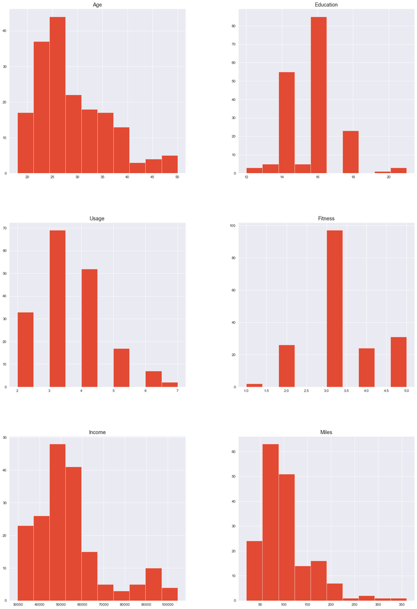

```python
# Histogram

%matplotlib inline
df.hist(figsize=(20,30), lw=.5);
```

#### 17a. Return the number of customers whose age is above one standard deviation from the mean

```python
age_count_beyond_first_std = df.loc[df['Age'] > 36, 'Age']

print(age_count_beyond_first_std.count(),'of the 180 treadmill customers are above the age of 36')
print('Only',round(age_count_beyond_first_std.count()/len(df)*100,2),'%', 'of the treadmill customers are above the age 36')
```

```
27 of the 180 treadmill customers are above the age of 36
Only 15.0 % of the treadmill customers are above the age 36
```

#### 17b. Return the number of customers who have not graduated from college (have less than 16 years of education)

```python
not_collegeEducated = df.loc[df['Education'] < 16, 'Education']

print(not_collegeEducated.count(), 'of the 180 treadmill customers are not college educated')
print(round(not_collegeEducated.count()/len(df)*100,2),'%', 'of the treadmill customers are not college educated')
```

```
68 of the 180 treadmill customers are not college educated
37.78 % of the treadmill customers are not college educated
```

#### 17c. Return the number of customers who plan to use their treadmill either six (6) or seven (7) times per week

```python
very_ambitious = df.loc[df['Usage'] >= 6, 'Usage']

print(very_ambitious.count(), 'of the 180 treadmill customers intend to use the treadmill at least 6 or 7 times per week')
print(round(very_ambitious.count()/len(df)*100,2),'%', "of the treadmill customers intend to use the treadmill at least 6 or 7 times per week")
```

```
9 of the 180 treadmill customers intend to use the treadmill at least 6 or 7 times per week
5.0 % of the treadmill customers intend to use the treadmill at least 6 or 7 times per week
```

#### 17d. Return the number of customers who rank their fitness at either a one (1) or a two (2)

```python
need_motivation = df.loc[df['Fitness'] <= 2, 'Fitness']

print(need_motivation.count(), 'of the 180 treadmill customers rank their fitness below at 2, so these folks may require encouragement and movtivation')
print(round(need_motivation.count()/len(df)*100,2),'%', 'of the treadmill customers rank their fitness below a 2, so these folks may require encouragement and motivation')
```

```
28 of the 180 treadmill customers rank their fitness below at 2, so these folks may require encouragement and movtivation
15.56 % of the treadmill customers rank their fitness below a 2, so these folks may require encouragement and motivation
```

#### 17e. Return the number of customers who earn less than 70K dollars per year

```python
seventy_K_or_less = df.loc[df['Income'] < 70000, 'Income']

print(seventy_K_or_less.count(), 'of the 180 treadmill customers earn less than $70,000')
print(round(seventy_K_or_less.count()/len(df)*100,2), '%', 'of the treadmill customers earn less than $70,000')
```

```
157 of the 180 treadmill customers earn less than $70,000
87.22 % of the treadmill customers earn less than $70,000
```

#### 17f. Return the number of customers who expect to run 94 miles or more per week (94 is the median miles value in the dataset).

```python
above_50th_percentile = df.loc[df['Miles'] >= 94, 'Miles']

print(above_50th_percentile.count(), 'of the 180 treadmill customers expect to run 94 miles or more per week')
print(round(above_50th_percentile.count()/len(df)*100,2), '%', 'of the treadmill customers expect to run 94 miles or more per week')
```

```
93 of the 180 treadmill customers expect to run 94 miles or more per week
51.67 % of the treadmill customers expect to run 94 miles or more per week
```

### 18. Return a density estimate that approximates a curve for the attribute age

#### 18a. Age -- OBSERVATION: mean > median; positively skewed distribution; most customers are in thier 20's

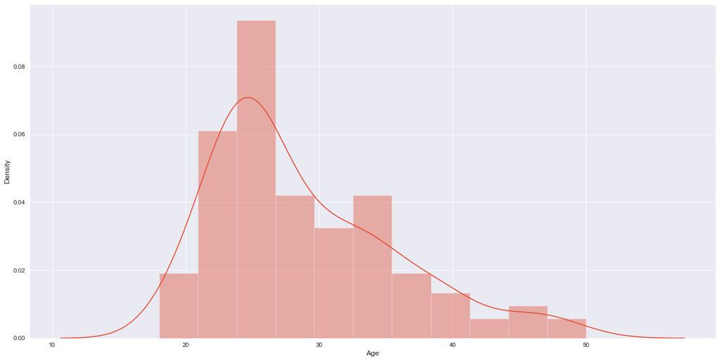

```python
# Kernel Density Estimate

plt.figure(figsize=(20,10))
sns.distplot(df['Age']);
```

### 19. Return a boxplot for education and evaluate the five-number summary distribution and any outliers

#### 19a. Education -- OBSERVATIONS: two (2) outlier data points exist beyond 1.5 times the interquartile range

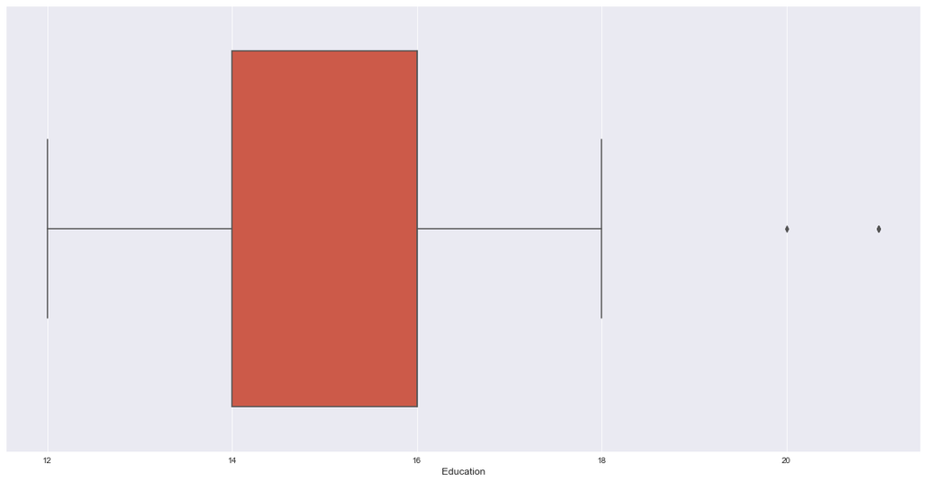

```python
# Boxplot

plt.figure(figsize=(20,10))
sns.boxplot(df['Education']);
```

### 20. Return a boxplot for income and evaluate the five-number summary distribution and any outliers

#### 20a. Income -- OBSERVATION: eleven (11) outlier data points exist beyond 1.5 times the interquartile range

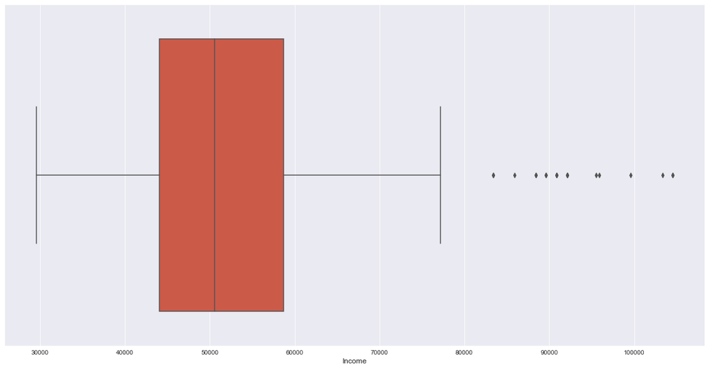

```python
# Boxplot

plt.figure(figsize=(20,10))
sns.boxplot(df['Income']);
```

### Multivariate Analysis

1. Pairplot -- Multivariate array of scatterplots and main-axis histograms for the Pandas dataframe named "df"
2. Correlation Coefficient Matrix -- Multivariate normalized version of covariance for Pandas dataframe named "df"
3. Heatmap -- Multivariate visualization of the correlation coefficient matrix

### Bivariate Analysis

1. Boxplot -- Bivariate five-number summary image for two (2) series attributes, (categorical product & quantitative age)
2. Countplot -- Count categorical series attribute against another categorical series attribute (qualitative & qualitative)
3. Crosstab -- Compute a frequency table of two (2) categorical attributes
4. Boxplot -- Bivariate five-number summary image for two (2) series attributes, (categorical gender & quantitative age)
5. Equality Operator and Arithmetic Operator -- Interquartile Range of the Age attribute for both males and females

### Multivariate Analysis

1. Groupby -- Product value to describe the five-number summary for each numeric attribute
2. Groupby -- Product value to compute the mean for each numeric attribute
3. Groupby -- Product value and Gender to compute the total males and females per treadmill
4. Groupby -- Product value and Gender to compute the mean Age per gender per treadmill
5. Groupby -- Product value and Gender to compute the aggregated mean of customers' Income for each product
6. Catplot -- Multivariate category plot that depicts Income vs. Gender vs. Product vs. Marital Status

### Creating Bins

1. Bins -- Step-by-Step process on the Income attribute to understand qcut() vs. cut()

### 21. Return a pairplot depicting attribute relationships for the Pandas dataframe named "df"

#### 21a. OBSERVATION: Income vs. Age -- in general, income values rise with age (positive relationship)

#### 21b. OBSERVATION: Covariances -- at this stage of my development, I have difficulty seeing/interpreting any relationships in a scatterplot other than linear relationships

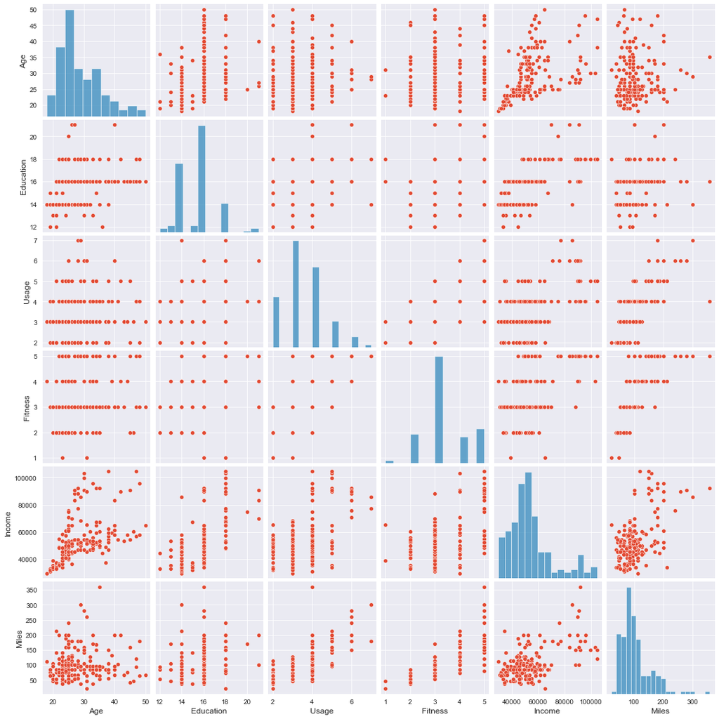

```python
# Multivariate array of scatterplot graphs and main diagonal histograms

sns.pairplot(df);
```

### 22. Return a correlation coefficient matrix for the Pandas dataframe named "df"

#### 22a. OBSERVATION: Usage and miles -- Strong (High) positive correlation -- note: ask someone about "strong" vs, "high"

#### 22b. OBSERVATION: Miles and Fitness -- Strong (High) positive correlation -- note: ask someone about "strong" vs, "high"

#### 22c. OBSERVATION: Usage and Age -- Weak (Low) correlation between usage and age -- note: ask someone about "strong" vs. "high"

```python
# Multivariate pairwise correlation of numeric attributes in the dataframe
correlation = df.corr()
correlation
```

|  | Age | Education | Usage | Fitness | Income | Miles |
| --- | --- | --- | --- | --- | --- | --- |
| Age | 1.000000 | 0.280496 | 0.015064 | 0.061105 | 0.513414 | 0.036618 |
| Education | 0.280496 | 1.000000 | 0.395155 | 0.410581 | 0.625827 | 0.307284 |
| Usage | 0.015064 | 0.395155 | 1.000000 | 0.668606 | 0.519537 | 0.759130 |
| Fitness | 0.061105 | 0.410581 | 0.668606 | 1.000000 | 0.535005 | 0.785702 |
| Income | 0.513414 | 0.625827 | 0.519537 | 0.535005 | 1.000000 | 0.543473 |
| Miles | 0.036618 | 0.307284 | 0.759130 | 0.785702 | 0.543473 | 1.000000 |

### 23. Return a heatmap depicting correlations for the Pandas dataframe named "df"

#### 23a. Normalization by the corr() function decreases the "units of measurements" bias by creating a correlation coefficient

OBSERVATIONS: listed in #22 above

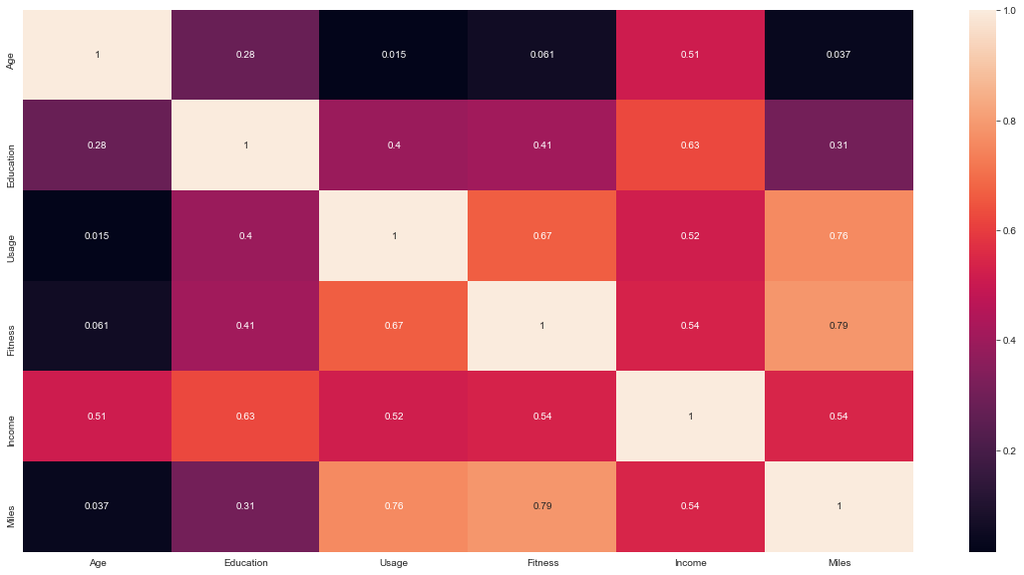

```python
# Multivariate Heatmap

plt.figure(figsize=(20,10))
sns.heatmap(correlation, annot=True);
```

### Bivariate Analysis

### 24. Return a boxplot that depicts age vs. treadmill model

#### 24a. OBSERVATION: Age vs. Product -- median age for TM195 & TM498 are similar (26 y/o), while median age for TM798 is slightly higher.

#### 24b. OBSERVATION: Age vs. Product -- older folks tend to purchase treadmill model number TM798 (outliers are 1.5 times above the IQR)

#### 24b. OBSERVATION: Age vs. Product -- longer whiskers above the 75th percentile for TM195 and TM498

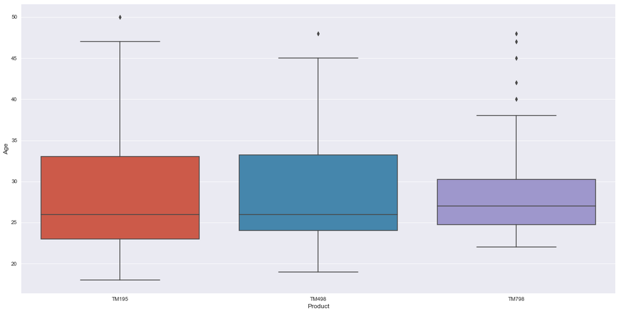

```python
# Bivariate Boxplot (continuous ratio-scaled vs categorical)

plt.figure(figsize=(20,10))
sns.boxplot(df['Product'], df['Age']);
```

### 25. Return a countplot that depicts customer gender vs product

#### 25a. OBSERVATION: Gender vs Product -- few women have purchased TM798 (the treadmill favored by older customers).

#### 25b. OBSERVATION: Gender vs. Product -- TM195 is the most popular treadmill, and it is evenly favored by both genders

#### 25b. OBSERVATION: Gender vs.Product -- from a sales/marketing perspective, TM498 is basically favored equally by both genders

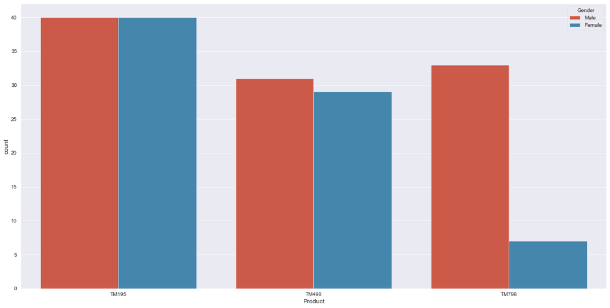

```python
# Bivariate Boxplot (categorical vs categorical)

plt.figure(figsize=(20,10))
sns.countplot(x='Product', hue='Gender', data=df);
```

### 26. Return a table that counts the purchases of each treadmill model by gender (crosstab)

#### 26a. OBSERVATION: Gender vs. Product -- only 7 woman have purchased TM798 (the treadmill favored by older customers).

```python
# accompanies countplot for question 25 (above)
# Bivariate crosstab

pd.crosstab(df['Product'],df['Gender'])
```

| Gender Product | Female | Male |
| --- | --- | --- |
| TM195 | 40 | 40 |
| TM498 | 29 | 31 |
| TM798 | 7 | 33 |

### 27. Return a boxplot that depicts customer age vs gender

#### 27a. age vs. gender -- OBSERVATION: the median age for both genders is similar (~26 y/o).

#### 27b. age vs. gender -- OBSERVATION: although the male box is slightly bigger than the female box, both genders have a very similar IQR

#### 27b. age vs. gender -- OBSERVATION: there is an interesting female outlier who may be the oldest of all the treadmill customers

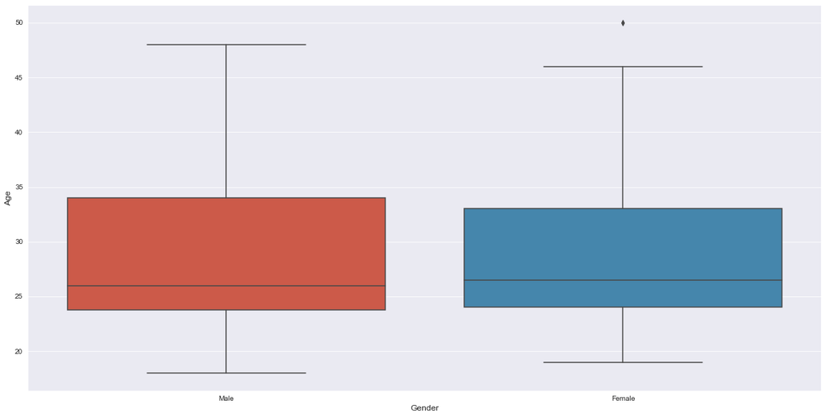

```python
# Bivariate Boxplot

plt.figure(figsize=(20,10))
sns.boxplot(df['Gender'], df['Age']);
```

### 28. Return the Interquartile Range of the Age attribute for both males and females

```python
# Bivariate age IQR for females and males (per my observation 26b above)

female_age_iqr3 = df[df['Gender'] == 'Female']['Age'].quantile(.75)
female_age_iqr1 = df[df['Gender'] == 'Female']['Age'].quantile(.25)
female_age_iqr = female_age_iqr3 - female_age_iqr1

male_age_iqr3 = df[df['Gender'] == 'Male']['Age'].quantile(.75)
male_age_iqr1 = df[df['Gender'] == 'Male']['Age'].quantile(.25)
male_age_iqr = male_age_iqr3 - male_age_iqr1

print('The age IQR for females is', female_age_iqr)
print("")
print('The age IQR for males is', male_age_iqr)
```

```
The age IQR for females is 9.0

The age IQR for males is 10.25
```

### Multivariate Analysis

### 29. Return a table row for each treadmill model such that it describes all of the numeric attributes

#### 29a. OBSERVATION: Product vs. Numeric Attributes -- five-number summary is described for each numeric attribute

```python
# Multivariate Table
# GROUPBY: 1) "What column do I want to group by?" 2) "On what column is the data being retrieved (and subsequently aggregated)?"

grouped_treadmills = df.groupby(['Product'])
grouped_treadmills.describe()
```

| Product | Age count | Age mean | Age std | Age min | Age 25% | Age 50% | Age 75% | Age max | Education count | Education mean | ... | Income 75% | Income max | Miles count | Miles mean | Miles std | Miles min | Miles 25% | Miles 50% | Miles 75% | Miles max |
| --- | --- | --- | --- | --- | --- | --- | --- | --- | --- | --- | --- | --- | --- | --- | --- | --- | --- | --- | --- | --- | --- |
| TM195 | 80.0 | 28.55 | 7.221452 | 18.0 | 23.00 | 26.0 | 33.00 | 50.0 | 80.0 | 15.037500 | ... | 53439.0 | 68220.0 | 80.0 | 82.787500 | 28.874102 | 38.0 | 66.0 | 85.0 | 94.0 | 188.0 |
| TM498 | 60.0 | 28.90 | 6.645248 | 19.0 | 24.00 | 26.0 | 33.25 | 48.0 | 60.0 | 15.116667 | ... | 53439.0 | 67083.0 | 60.0 | 87.933333 | 33.263135 | 21.0 | 64.0 | 85.0 | 106.0 | 212.0 |
| TM798 | 40.0 | 29.10 | 6.971738 | 22.0 | 24.75 | 27.0 | 30.25 | 48.0 | 40.0 | 17.325000 | ... | 90886.0 | 104581.0 | 40.0 | 166.900000 | 60.066544 | 80.0 | 120.0 | 160.0 | 200.0 | 360.0 |

3 rows × 48 columns

### 30. Return a table row for each treadmill model such that it lists the mean for all numeric attributes

#### 30a. OBSERVATION: Product vs. Numeric mean of Attributes -- older people who bought TM798 have higher averages overall

```python
# Multivariate Table
# GROUPBY: "What column do I want to group by?" "On what column is the data being retrieved (and subsequently aggregated)?"
# OBSERVATION: TM798 has the highest averages accross all attribute features
# OBSERVATION: TM798 (166.90 Miles/week) / (4.78 Uses/week) = (34.92 miles/use) -- 35 miles of exercise per day on a treadmill!

round(grouped_treadmills.mean(),2)
```

| Product | Age | Education | Usage | Fitness | Income | Miles |
| --- | --- | --- | --- | --- | --- | --- |
| TM195 | 28.55 | 15.04 | 3.09 | 2.96 | 46418.02 | 82.79 |
| TM498 | 28.90 | 15.12 | 3.07 | 2.90 | 48973.65 | 87.93 |
| TM798 | 29.10 | 17.32 | 4.78 | 4.62 | 75441.58 | 166.90 |

### 31. Return a table grouped by model and gender that shows the total number of customers for each product

#### 31a. OBSERVATION: product & gender -- this groupby is similar to the bivariate crosstab for product & gender

```python
# Groupby Function

df.groupby(['Product', 'Gender'])['Product'].count().reset_index(name='Count')
```

|  | Product | Gender | Count |
| --- | --- | --- | --- |
| 0 | TM195 | Female | 40 |
| 1 | TM195 | Male | 40 |
| 2 | TM498 | Female | 29 |
| 3 | TM498 | Male | 31 |
| 4 | TM798 | Female | 7 |
| 5 | TM798 | Male | 33 |

### 32. Return a table that shows the aggregated mean of customers' age by gender and for each product

#### 32a. OBSERVATION: product vs. gender vs. mean age -- comparing this groupby table with the describe() function, it becomes appearent that the overall mean age for the 180 customers (28.79) is fairly similar to all of the mean ages that are parceled out in this table. It might not be fair to assume that TM798 is only meant for "older" customers.

```python
# Groupby Function

df.groupby(['Product', 'Gender'])['Age'].mean().reset_index(name='Mean Age').round(2)
```

|  | Product | Gender | Mean Age |
| --- | --- | --- | --- |
| 0 | TM195 | Female | 28.45 |
| 1 | TM195 | Male | 28.65 |
| 2 | TM498 | Female | 29.10 |
| 3 | TM498 | Male | 28.71 |
| 4 | TM798 | Female | 27.00 |
| 5 | TM798 | Male | 29.55 |

### 33. Return a table that shows the aggregated mean of customers' income for each product

#### 33a. OBSERVATION: product & gender -- this groupby indicates that, for each treadmill model, income averages do dot vary much between males and females; in fact, for TM498 the female average income is more than the male average income

```python
# Groupby Function

df.groupby(['Product', 'Gender'])['Income'].mean().reset_index(name='Mean Income').round(2)
```

|  | Product | Gender | Mean Income |
| --- | --- | --- | --- |
| 0 | TM195 | Female | 46020.08 |
| 1 | TM195 | Male | 46815.98 |
| 2 | TM498 | Female | 49336.45 |
| 3 | TM498 | Male | 48634.26 |
| 4 | TM798 | Female | 73633.86 |
| 5 | TM798 | Male | 75825.03 |

### 34. Return a multivariate category plot that depicts income vs. gender vs. product vs. marital status

#### 34a. OBSERVATION: income vs. gender vs. product vs. marital status -- the income level of those customers who own TM798 noticably skews the boxplots upward for that product. However, the TM798 box that represents 50% of the 'single males' who use that treadmill and the TM798 box that represents 50% of the 'single females' who use that treadmill both have overall lower income levels (and median income levels) than the income levels of the 'partnered males' and 'partnered females'.

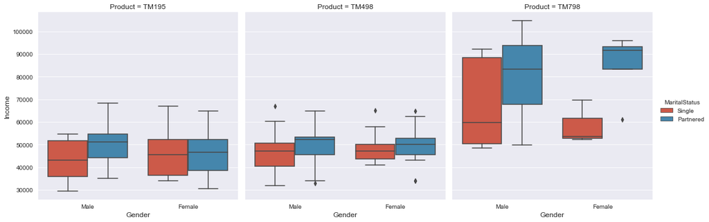

```python
# Multivariate Catplot

sns.catplot(x="Gender", y="Income", hue="MaritalStatus",col="Product", data=df, kind="box");
```

### Creating Bins

### Continuous Numeric Data

Binning Data with Pandas qcut() and cut()

https://pbpython.com/pandas-qcut-cut.html

### 35. Return a univariate histogram plot that depicts income

#### 35a. OBSERVATION: income bins -- there are 10 pandas-generated income bins for 180 data objects

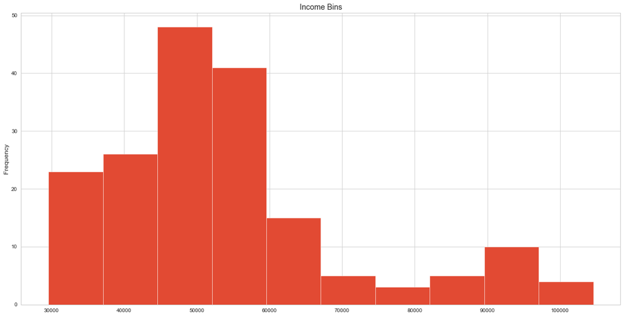

```python
# Raw Data -- Income Bins (matplotlib-sns "bucketing/discrete binning/discretization/quantization")
# Observation: raw income data yields 10 bins for 180 data objects

sns.set_style('whitegrid')
plt.figure(figsize=(20,10))

df['Income'].plot(kind='hist', title='Income Bins');
```

### 34. Return a univariate histogram plot that depicts median income on a new groupby dataframe

##### Step 1: Compare Q1, Q2, Q3 among raw-income binned data and median-income binned data

##### Step 2: Use qcut() to define the number of quantiles (4, 6, and 10) and then pandas figures out how to divide up the data

##### Step 3: Create new columns for the newly binnned quantiles (4, 6, and 10)

##### Step 4: Display how the values are distributed across the bins for each new bin quantile

##### Step 5: Label the bins

##### Step 6: Display how the values are distributed across the labeled bins

##### Step 7: Create a table to express the income thresholds/ranges for each tiered bin

##### Step 8: Describe the grouped dataframe in terms of categorical values

##### Step 9: Describe the grouped dataframe using percentiles

##### Step 10: Rather than bin ranges or bin labels, return integer rankings

##### Step 11: Use cut() to specifically define the bin edges

##### Step 12: Display how the values are distributed across the defined bins

##### Step 13: Define bin parameters

##### Step 14: Use numpy linspace function to compactly create bin ranges

##### Step 15: Display how the values are distributed across the evenly spaced bins

Binning Data with Pandas qcut and cut https://pbpython.com/pandas-qcut-cut.html

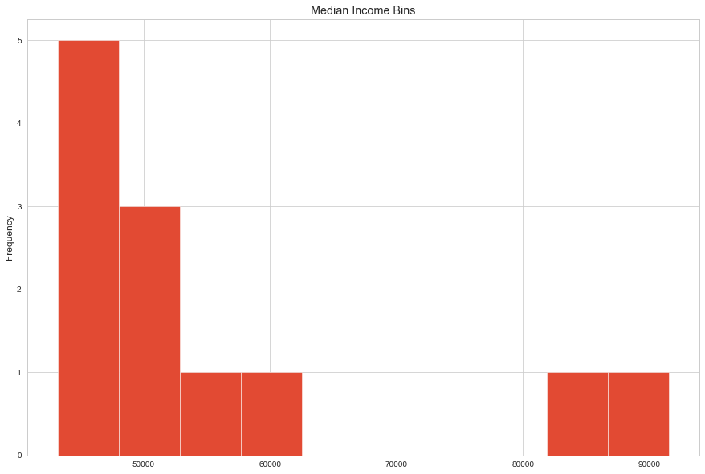

```python
# Aggregated Data -- Median Income Bins (matplotlib-sns "bucketing/discrete binning/discretization/quantization")
# Summarize median income information for treadmill customers grouped by product, gender, and marital status
# Observation: aggregating income data (median) yields 6 bins for 12 data objects

sns.set_style('whitegrid')
plt.figure(figsize=(15,10))

# GROUPBY: "What column(s) do I want to group by?" "On what column is the data being retrieved (and subsequently aggregated)?"
grouped = df.groupby(['Product', 'Gender', 'MaritalStatus'])['Income'].median().reset_index()
grouped['Income'].plot(kind='hist', title='Median Income Bins');
```

```python
# Step 1:
# Herein, I compare Q1, Q2, Q3 among raw-income binned data and median-income binned data
# OBSERVATION: There are 180 raw data objects vs. 12 aggregated data objects
# OBSERVATION: As expected, Q2/50% is the same for both the raw value and the aggregated value
# OBSERVATION: As expected, the min-median value > min-raw value and the Q1/25%-median value > Q1/25%-raw value
# OBSERVATION: As expected, the max-median value < max-raw value and the Q3/75%-median value < Q3/75%-raw value

raw_income_bin = df['Income'].describe()
median_income_bin = grouped['Income'].describe()

print('Raw Income Bins:', raw_income_bin)
print("")
print('Meidan Income Bins:', median_income_bin)
```

```
Raw Income Bins: count       180.000000
mean      53719.577778
std       16506.684226
min       29562.000000
25%       44058.750000
50%       50596.500000
75%       58668.000000
max      104581.000000
Name: Income, dtype: float64

Meidan Income Bins: count       12.000000
mean     55949.208333
std      15442.508175
min      43206.000000
25%      47043.375000
50%      50596.500000
75%      55092.250000
max      91508.500000
Name: Income, dtype: float64
```

```python
# Step 2:
# Use qcut() to define quantile-based discretionization bins based on the distribution of the data
# Herein , I define the number of quantiles (4, 6, and 10) and then pandas figures out how to divide up the data
# OBSERVATION: For each new bin structure, the minimum median income is 43,205.99 and the maximum median income is 91,508.50
# OBSERVATION: However, the intervals for median income vary for each of the remainder of the quantile-based bin structures
# OBSERVATION: No matter the number of quantiles (4, 6, 10), the number of data objects remains at 12
# OBSERVATION: Note the "Categories" at the end of each quantile.

quartile = pd.qcut(grouped['Income'], q=4, precision=2)
hexile = pd.qcut(grouped['Income'], q=6, precision=2)
decile = pd.qcut(grouped['Income'], q=10, precision=2)

print('Quartile:', quartile)
print('')
print('Hexile:', hexile)
print('')
print('Decile:', decile)
print('')
```

```
Quartile: 0     (43205.99, 47043.38]
1     (43205.99, 47043.38]
2      (50596.5, 55092.25]
3     (43205.99, 47043.38]
4      (47043.38, 50596.5]
5      (47043.38, 50596.5]
6      (50596.5, 55092.25]
7      (47043.38, 50596.5]
8      (55092.25, 91508.5]
9      (50596.5, 55092.25]
10     (55092.25, 91508.5]
11     (55092.25, 91508.5]
Name: Income, dtype: category
Categories (4, interval[float64]): [(43205.99, 47043.38] < (47043.38, 50596.5] < (50596.5, 55092.25] < (55092.25, 91508.5]]

```

[output cut: 29 more lines]

```python
# Step 3:
# Herein, I create new columns for the newly binnned income quantiles (4, 6, and 10)
# OBSERVATION: Interval notation: open/closed bracket means "included" while open/closed paraenthesis means "excluded"

grouped['Four_Bin_Income'] = pd.qcut(grouped['Income'], q=4, precision=2)
grouped['Six_Bin_Income'] = pd.qcut(grouped['Income'], q=6, precision=2)
grouped['Ten_Bin_Income'] = pd.qcut(grouped['Income'], q=10, precision=2)
#grouped.rename(columns={'Income': 'Median Income'}, inplace=True)
grouped
```

|  | Product | Gender | MaritalStatus | Income | Four_Bin_Income | Six_Bin_Income | Ten_Bin_Income |
| --- | --- | --- | --- | --- | --- | --- | --- |
| 0 | TM195 | Female | Partnered | 46617.0 | (43205.99, 47043.38] | (46427.5, 47185.5] | (45593.7, 46730.7] |
| 1 | TM195 | Female | Single | 45480.0 | (43205.99, 47043.38] | (43205.99, 46427.5] | (43205.99, 45593.7] |
| 2 | TM195 | Male | Partnered | 51165.0 | (50596.5, 55092.25] | (50596.5, 52713.33] | (50596.5, 51847.2] |
| 3 | TM195 | Male | Single | 43206.0 | (43205.99, 47043.38] | (43205.99, 46427.5] | (43205.99, 45593.7] |
| 4 | TM498 | Female | Partnered | 50028.0 | (47043.38, 50596.5] | (47185.5, 50596.5] | (48322.5, 50596.5] |
| 5 | TM498 | Female | Single | 47185.5 | (47043.38, 50596.5] | (46427.5, 47185.5] | (46730.7, 47185.5] |
| 6 | TM498 | Male | Partnered | 52302.0 | (50596.5, 55092.25] | (50596.5, 52713.33] | (51847.2, 53165.8] |
| 7 | TM498 | Male | Single | 47185.5 | (47043.38, 50596.5] | (46427.5, 47185.5] | (46730.7, 47185.5] |
| 8 | TM798 | Female | Partnered | 91508.5 | (55092.25, 91508.5] | (63703.5, 91508.5] | (81050.5, 91508.5] |
| 9 | TM798 | Female | Single | 53536.0 | (50596.5, 55092.25] | (52713.33, 63703.5] | (53165.8, 58516.0] |
| 10 | TM798 | Male | Partnered | 83416.0 | (55092.25, 91508.5] | (63703.5, 91508.5] | (81050.5, 91508.5] |
| 11 | TM798 | Male | Single | 59761.0 | (55092.25, 91508.5] | (52713.33, 63703.5] | (58516.0, 81050.5] |

```python
# Step 4:
# Display how the values are distributed across the bins for each new bin quantile
# OBSERVATION: 4_bins -- pandas distributes the 12 median values evenly, three (3) per bin
# OBSERVATION: 6_bins -- pandas tries to distribute the 12 median values evenly
# OBSERVATION: 10_bins -- pandas tries to distribute the 12 median values evenly

print(grouped['Four_Bin_Income'].value_counts())
print('')
print(grouped['Six_Bin_Income'].value_counts())
print('')
print(grouped['Ten_Bin_Income'].value_counts())
print('')
```

```
(55092.25, 91508.5]     3
(50596.5, 55092.25]     3
(47043.38, 50596.5]     3
(43205.99, 47043.38]    3
Name: Four_Bin_Income, dtype: int64

(46427.5, 47185.5]     3
(63703.5, 91508.5]     2
(52713.33, 63703.5]    2
(50596.5, 52713.33]    2
(43205.99, 46427.5]    2
(47185.5, 50596.5]     1
Name: Six_Bin_Income, dtype: int64

(81050.5, 91508.5]     2
(46730.7, 47185.5]     2
(43205.99, 45593.7]    2
(58516.0, 81050.5]     1
(53165.8, 58516.0]     1
(51847.2, 53165.8]     1
(50596.5, 51847.2]     1
(48322.5, 50596.5]     1
(45593.7, 46730.7]     1
(47185.5, 48322.5]     0
Name: Ten_Bin_Income, dtype: int64
```

```python
# Step 5:
# Label the bins
# OBSERVATION: This is a subjective process and nomenclature decisions are not readily apparent
# OBSERVATION: Partnered Females and Partnered Males earn the highest incomes and tend to buy TM798

quartile_bin_labels = ['Low Income', 'Medium Income', 'Good Income', 'Excellent Income']
hexile_bin_labels = ['43.0K - 46.5K', '46.5K - 47.0K', '47.0K - 50.5K', '50.5K - 52.7K', '52.7K - 63.7K', '63.7K - 91.5K']
decile_bin_labels = ['first', 'second', 'third', 'fourth', 'fifth', 'sixth', 'seventh', 'eighth', 'ninth', 'tenth']

grouped['Quartiles'] = pd.qcut(grouped['Income'], q=4, precision=2, labels=quartile_bin_labels)
grouped['Hexiles'] = pd.qcut(grouped['Income'], q=6, precision=2, labels=hexile_bin_labels)
grouped['Deciles'] = pd.qcut(grouped['Income'], q=10, precision=2, labels= decile_bin_labels)
#grouped.rename(columns={'Income': 'Median_Income'}, inplace=True)
grouped
```

|  | Product | Gender | MaritalStatus | Income | Four_Bin_Income | Six_Bin_Income | Ten_Bin_Income | Quartiles | Hexiles | Deciles |
| --- | --- | --- | --- | --- | --- | --- | --- | --- | --- | --- |
| 0 | TM195 | Female | Partnered | 46617.0 | (43205.99, 47043.38] | (46427.5, 47185.5] | (45593.7, 46730.7] | Low Income | 46.5K - 47.0K | second |
| 1 | TM195 | Female | Single | 45480.0 | (43205.99, 47043.38] | (43205.99, 46427.5] | (43205.99, 45593.7] | Low Income | 43.0K - 46.5K | first |
| 2 | TM195 | Male | Partnered | 51165.0 | (50596.5, 55092.25] | (50596.5, 52713.33] | (50596.5, 51847.2] | Good Income | 50.5K - 52.7K | sixth |
| 3 | TM195 | Male | Single | 43206.0 | (43205.99, 47043.38] | (43205.99, 46427.5] | (43205.99, 45593.7] | Low Income | 43.0K - 46.5K | first |
| 4 | TM498 | Female | Partnered | 50028.0 | (47043.38, 50596.5] | (47185.5, 50596.5] | (48322.5, 50596.5] | Medium Income | 47.0K - 50.5K | fifth |
| 5 | TM498 | Female | Single | 47185.5 | (47043.38, 50596.5] | (46427.5, 47185.5] | (46730.7, 47185.5] | Medium Income | 46.5K - 47.0K | third |
| 6 | TM498 | Male | Partnered | 52302.0 | (50596.5, 55092.25] | (50596.5, 52713.33] | (51847.2, 53165.8] | Good Income | 50.5K - 52.7K | seventh |
| 7 | TM498 | Male | Single | 47185.5 | (47043.38, 50596.5] | (46427.5, 47185.5] | (46730.7, 47185.5] | Medium Income | 46.5K - 47.0K | third |
| 8 | TM798 | Female | Partnered | 91508.5 | (55092.25, 91508.5] | (63703.5, 91508.5] | (81050.5, 91508.5] | Excellent Income | 63.7K - 91.5K | tenth |
| 9 | TM798 | Female | Single | 53536.0 | (50596.5, 55092.25] | (52713.33, 63703.5] | (53165.8, 58516.0] | Good Income | 52.7K - 63.7K | eighth |
| 10 | TM798 | Male | Partnered | 83416.0 | (55092.25, 91508.5] | (63703.5, 91508.5] | (81050.5, 91508.5] | Excellent Income | 63.7K - 91.5K | tenth |
| 11 | TM798 | Male | Single | 59761.0 | (55092.25, 91508.5] | (52713.33, 63703.5] | (58516.0, 81050.5] | Excellent Income | 52.7K - 63.7K | ninth |

```python
# Step 6:
# Display how the values are distributed across the labeled bins
# OBSERVATION: Quartiles -- pandas distributes the 12 median values evenly, three (3) per bin
# OBSERVATION: Hexiles -- pandas tries to distribute the 12 median values evenly
# OBSERVATION: Deciles -- pandas tries to distribute the 12 median values evenly

print(grouped['Quartiles'].value_counts())
print('')
print(grouped['Hexiles'].value_counts())
print('')
print(grouped['Deciles'].value_counts())
print('')
```

```
Excellent Income    3
Good Income         3
Medium Income       3
Low Income          3
Name: Quartiles, dtype: int64

46.5K - 47.0K    3
63.7K - 91.5K    2
52.7K - 63.7K    2
50.5K - 52.7K    2
43.0K - 46.5K    2
47.0K - 50.5K    1
Name: Hexiles, dtype: int64

tenth      2
third      2
first      2
ninth      1
eighth     1
seventh    1
sixth      1
fifth      1
second     1
fourth     0
Name: Deciles, dtype: int64
```

```python
# Step 7:
# Create a table to express the income thresholds/ranges for each tiered bin
# OBSERVATION: I'm learning how to expand the number of bins so that I can eventually narrow down my ultimate bin selection

results_4, bin_edges_4 = pd.qcut(grouped['Income'], q=4, precision=2, labels=quartile_bin_labels, retbins=True)
results_6, bin_edges_6 = pd.qcut(grouped['Income'], q=6, precision=2, labels=hexile_bin_labels, retbins=True)
results_10, bin_edges_10 = pd.qcut(grouped['Income'], q=10, precision=2, labels= decile_bin_labels, retbins=True)

results_table_4 = pd.DataFrame(zip(bin_edges_4, quartile_bin_labels),
                            columns=['Income Threshold', 'Tier'])

results_table_6 = pd.DataFrame(zip(bin_edges_6, hexile_bin_labels),
                            columns=['Income Threshold', 'Tier'])

results_table_10 = pd.DataFrame(zip(bin_edges_10, decile_bin_labels),
                            columns=['Income Threshold', 'Tier'])
print(results_table_4)
print('')
print(results_table_6)
print('')
print(results_table_10)
print('')
```

```
   Income Threshold              Tier
0         43206.000        Low Income
1         47043.375     Medium Income
2         50596.500       Good Income
3         55092.250  Excellent Income

   Income Threshold           Tier
0      43206.000000  43.0K - 46.5K
1      46427.500000  46.5K - 47.0K
2      47185.500000  47.0K - 50.5K
3      50596.500000  50.5K - 52.7K
4      52713.333333  52.7K - 63.7K
5      63703.500000  63.7K - 91.5K

   Income Threshold     Tier
0           43206.0    first
1           45593.7   second
2           46730.7    third
3           47185.5   fourth
4           48322.5    fifth
5           50596.5    sixth
6           51847.2  seventh
7           53165.8   eighth
8           58516.0    ninth
9           81050.5    tenth
```

```python
# Step 8:
# Describe the grouped dataframe in terms of categorical values
# OBSERVATION: a bin remains empty for the Ten_Bin / Deciles median income category

grouped.describe(include='category')
```

|  | Four_Bin_Income | Six_Bin_Income | Ten_Bin_Income | Quartiles | Hexiles | Deciles |
| --- | --- | --- | --- | --- | --- | --- |
| count | 12 | 12 | 12 | 12 | 12 | 12 |
| unique | 4 | 6 | 9 | 4 | 6 | 9 |
| top | (55092.25, 91508.5] | (46427.5, 47185.5] | (81050.5, 91508.5] | Excellent Income | 46.5K - 47.0K | tenth |
| freq | 3 | 3 | 2 | 3 | 3 | 2 |

```python
# Step 9:
# Describe the grouped dataframe using percentiles
# OBSERVATION: 0% = min and 100% = max
# OBSERVATION: I need help/tutoring; I'm confused about describing an aggregaed dataframe
# OBSERVATION: I need help/tutoring; I'm confused about how renaming a column (as I tried numerous times above) disrupts the execution of subsequent cells

#grouped.rename(columns={'Income': 'Median_Income'}, inplace=True)
grouped.describe(percentiles=[0,1/4,1/3,2/3,3/4,1])
```

|  | Income |
| --- | --- |
| count | 12.000000 |
| mean | 55949.208333 |
| std | 15442.508175 |
| min | 43206.000000 |
| 0% | 43206.000000 |
| 25% | 47043.375000 |
| 33.3% | 47185.500000 |
| 50% | 50596.500000 |
| 66.7% | 52713.333333 |
| 75% | 55092.250000 |
| 100% | 91508.500000 |
| max | 91508.500000 |

```python
# Step 10:
# Rather than bin ranges or bin labels, return integer rankings
# OBSERVATION: Single Males and Single Females rank lowest and tend to purchase TM195

grouped['Integer_Rank_4_bins'] = pd.qcut(grouped['Income'], q=4, precision=2, labels=False)
grouped['Integer_Rank_6_bins'] = pd.qcut(grouped['Income'], q=6, precision=2, labels=False)
grouped['Integer_Rank_10_bins'] = pd.qcut(grouped['Income'], q=10, precision=2, labels= False)
#grouped.rename(columns={'Income': 'Median_Income'}, inplace=True)
grouped
```

|  | Product | Gender | MaritalStatus | Income | Four_Bin_Income | Six_Bin_Income | Ten_Bin_Income | Quartiles | Hexiles | Deciles | Integer_Rank_4_bins | Integer_Rank_6_bins | Integer_Rank_10_bins |
| --- | --- | --- | --- | --- | --- | --- | --- | --- | --- | --- | --- | --- | --- |
| 0 | TM195 | Female | Partnered | 46617.0 | (43205.99, 47043.38] | (46427.5, 47185.5] | (45593.7, 46730.7] | Low Income | 46.5K - 47.0K | second | 0 | 1 | 1 |
| 1 | TM195 | Female | Single | 45480.0 | (43205.99, 47043.38] | (43205.99, 46427.5] | (43205.99, 45593.7] | Low Income | 43.0K - 46.5K | first | 0 | 0 | 0 |
| 2 | TM195 | Male | Partnered | 51165.0 | (50596.5, 55092.25] | (50596.5, 52713.33] | (50596.5, 51847.2] | Good Income | 50.5K - 52.7K | sixth | 2 | 3 | 5 |
| 3 | TM195 | Male | Single | 43206.0 | (43205.99, 47043.38] | (43205.99, 46427.5] | (43205.99, 45593.7] | Low Income | 43.0K - 46.5K | first | 0 | 0 | 0 |
| 4 | TM498 | Female | Partnered | 50028.0 | (47043.38, 50596.5] | (47185.5, 50596.5] | (48322.5, 50596.5] | Medium Income | 47.0K - 50.5K | fifth | 1 | 2 | 4 |
| 5 | TM498 | Female | Single | 47185.5 | (47043.38, 50596.5] | (46427.5, 47185.5] | (46730.7, 47185.5] | Medium Income | 46.5K - 47.0K | third | 1 | 1 | 2 |
| 6 | TM498 | Male | Partnered | 52302.0 | (50596.5, 55092.25] | (50596.5, 52713.33] | (51847.2, 53165.8] | Good Income | 50.5K - 52.7K | seventh | 2 | 3 | 6 |
| 7 | TM498 | Male | Single | 47185.5 | (47043.38, 50596.5] | (46427.5, 47185.5] | (46730.7, 47185.5] | Medium Income | 46.5K - 47.0K | third | 1 | 1 | 2 |
| 8 | TM798 | Female | Partnered | 91508.5 | (55092.25, 91508.5] | (63703.5, 91508.5] | (81050.5, 91508.5] | Excellent Income | 63.7K - 91.5K | tenth | 3 | 5 | 9 |
| 9 | TM798 | Female | Single | 53536.0 | (50596.5, 55092.25] | (52713.33, 63703.5] | (53165.8, 58516.0] | Good Income | 52.7K - 63.7K | eighth | 2 | 4 | 7 |
| 10 | TM798 | Male | Partnered | 83416.0 | (55092.25, 91508.5] | (63703.5, 91508.5] | (81050.5, 91508.5] | Excellent Income | 63.7K - 91.5K | tenth | 3 | 5 | 9 |
| 11 | TM798 | Male | Single | 59761.0 | (55092.25, 91508.5] | (52713.33, 63703.5] | (58516.0, 81050.5] | Excellent Income | 52.7K - 63.7K | ninth | 3 | 4 | 8 |

```python
# Step 11:
# Use cut() to specifically define the bin edges (begin with 4 bins)
# OBSERVATION: "Categories" is 4

pd.cut(grouped['Income'], bins=4)
```

```
0     (43157.698, 55281.625]
1     (43157.698, 55281.625]
2     (43157.698, 55281.625]
3     (43157.698, 55281.625]
4     (43157.698, 55281.625]
5     (43157.698, 55281.625]
6     (43157.698, 55281.625]
7     (43157.698, 55281.625]
8       (79432.875, 91508.5]
9     (43157.698, 55281.625]
10      (79432.875, 91508.5]
11     (55281.625, 67357.25]
Name: Income, dtype: category
Categories (4, interval[float64]): [(43157.698, 55281.625] < (55281.625, 67357.25] < (67357.25, 79432.875] < (79432.875, 91508.5]]
```

```python
# Step 12:
# Display how the values are distributed across the four (4) bins
# OBSERVATION: Unlike quantized bin structure, the distribution of objects into these four (4) bins is uneven

pd.cut(grouped['Income'], bins=4).value_counts()
```

```
(43157.698, 55281.625]    9
(79432.875, 91508.5]      2
(55281.625, 67357.25]     1
(67357.25, 79432.875]     0
Name: Income, dtype: int64
```

```python
# Step 13:
# Define bin parameters

# drop quantiles columns
#grouped = grouped.drop(columns = ['Four_Bin_Income', 'Six_Bin_Income', 'Ten_Bin_Income', 'Quartiles', 'Hexiles', 'Deciles', 'Integer_Rank_4_bins', 'Integer_Rank_6_bins', 'Integer_Rank_10_bins'])

user_defined_bin_labels = ['Low Income', 'Medium Income', 'Good Income', 'Excellent Income']
cut_bins = [0, 45000, 65000 , 80000, 125000]
grouped['Income Levels'] = pd.cut(grouped['Income'], bins=cut_bins, labels=user_defined_bin_labels)
#grouped.rename(columns={'Income': 'Median_Income'}, inplace=True)
grouped
```

[output not shown]

```python
# Step 14:
# Use numpy linspace function to compactly create bin ranges
# OBSERVATION: linspace provides an array of evenly spaced numbers over a user defined range

pd.cut(grouped['Income'], bins=np.linspace(0, 125000, 5))
```

```
0     (31250.0, 62500.0]
1     (31250.0, 62500.0]
2     (31250.0, 62500.0]
3     (31250.0, 62500.0]
4     (31250.0, 62500.0]
5     (31250.0, 62500.0]
6     (31250.0, 62500.0]
7     (31250.0, 62500.0]
8     (62500.0, 93750.0]
9     (31250.0, 62500.0]
10    (62500.0, 93750.0]
11    (31250.0, 62500.0]
Name: Income, dtype: category
Categories (4, interval[float64]): [(0.0, 31250.0] < (31250.0, 62500.0] < (62500.0, 93750.0] < (93750.0, 125000.0]]
```

```python
# Step 15:
# Display how the values are distributed across the evenly spaced bins
# OBSERVATION: It's easier to see that 9 of the 12 aggregated income data objects fall within the first income range

grouped['Income'].value_counts(bins=4, sort=False)
```

```
(43157.697, 55281.625]    9
(55281.625, 67357.25]     1
(67357.25, 79432.875]     0
(79432.875, 91508.5]      2
Name: Income, dtype: int64
```

### Miscellaneous Computations

```python
# Miscellaneous Cell
# Income Standard Deviation (1-std)
lowerSigma1 = df['Income'].mean() - df['Income'].std()
upperSigma1 = df['Income'].mean() + df['Income'].std()
print(lowerSigma1)
print(upperSigma1)
```

```
37212.89355153916
70226.2620040164
```

```python
# Miscellaneous Cell
# Univariate Number of Values
df['Gender'].value_counts()
```

```
Male      104
Female     76
Name: Gender, dtype: int64
```

```python
# Miscellaneous Cell
# A simple dataframe of age and product

age_vs_prduct = df[['Age', 'Product']]
age_vs_prduct
```

|  | Age | Product |
| --- | --- | --- |
| 0 | 18 | TM195 |
| 1 | 19 | TM195 |
| 2 | 19 | TM195 |
| 3 | 19 | TM195 |
| 4 | 20 | TM195 |
| ... | ... | ... |
| 175 | 40 | TM798 |
| 176 | 42 | TM798 |
| 177 | 45 | TM798 |
| 178 | 47 | TM798 |
| 179 | 48 | TM798 |

180 rows × 2 columns

```python
# Miscellaneous Cell
# Univariate Count of Self-Rated 3
selfRated3 = df.loc[df['Fitness'] == 3, 'Fitness']
selfRated3.count()
```

```
97
```

```python
# Miscellaneous Cell
# Bivariate crosstab for the frequency of every data object by age

pd.crosstab(index=df['Age'],columns="Gender",margins=True, margins_name="Total")
```

| col_0 Age | Gender | Total |
| --- | --- | --- |
| 18 | 1 | 1 |
| 19 | 4 | 4 |
| 20 | 5 | 5 |
| 21 | 7 | 7 |
| 22 | 7 | 7 |
| 23 | 18 | 18 |
| 24 | 12 | 12 |
| 25 | 25 | 25 |
| 26 | 12 | 12 |
| 27 | 7 | 7 |
| 28 | 9 | 9 |
| 29 | 6 | 6 |
| 30 | 7 | 7 |
| 31 | 6 | 6 |
| 32 | 4 | 4 |
| 33 | 8 | 8 |
| 34 | 6 | 6 |
| 35 | 8 | 8 |
| 36 | 1 | 1 |
| 37 | 2 | 2 |
| 38 | 7 | 7 |
| 39 | 1 | 1 |
| 40 | 5 | 5 |
| 41 | 1 | 1 |
| 42 | 1 | 1 |
| 43 | 1 | 1 |
| 44 | 1 | 1 |
| 45 | 2 | 2 |
| 46 | 1 | 1 |
| 47 | 2 | 2 |
| 48 | 2 | 2 |
| 50 | 1 | 1 |
| Total | 180 | 180 |

### Observations of Univariate Attributes

1. Age - The average age of a treadmill customer is almost 29 years old.

   ```
     Youngest: 18, Oldest: 50
     Median Age: 26
     Mean > Median (herein, age is positively skewed attribute)
   ```

2. Education - The average number of schooling years of a treadmill customer is 15.5 years.

   ```
     Minimum: 12, Maximum: 21
     Median Schooling: 16
     Most treadmill customers have a college degree
   ```

3. Usage - The average number of times a treadmill customer expects to use the machine is 3.46 times per week.

   ```
     Minimum: 2, Maximum 7
     Median anticipated Usage: 3
     Fewer treadmill customers plan to use the machine 5, 6, or 7 times each week.
   ```

4. Fitness - The average self-rated fitness level by a treadmill customer was 3.31 out of a possible ranking of 5.

   ```
         Of the 180 treadmill customers, 97 ranked their fitness a 3.
   ```

5. Income - The average income of a treadmill customer is 53,719.58 USD whereas the median income is 50,596.50 USD

   ```
         Mean > Median (herein, income is a positively skewed attribute)
         Approximately 68% of all treadmill customers have an income between $37,212.90 and $70,226.26
   ```

6. Miles - The average number of miles that a treadmill customer expects to run each week is 103

   ```
         Minimum: 21, Maximum 360
         Median anticipated miles: 94
         Interquartile Range: 114.75 - 66.00 = 48.75
        Median anticipated miles / Median anticipated usage: folks think that they can run 31.3 miles per session
   ```

### Observations of Multivariate Attribute Relationships

OBSERVATION: Income vs. Age -- in general, income values rise with age (positive relationship)

OBSERVATION: Covariances -- at this stage of my development, I have difficulty seeing/interpreting any relationships in a scatterplot other than linear relationships

OBSERVATION: Usage and miles -- Strong (High) positive correlation between usage and miles.

OBSERVATION: Miles and Fitness -- Strong (High) positive correlation between miles and fitness.

OBSERVATION: Usage and Age -- Weak (Low) correlation between usage and age.

OBSERVATION: Normalization by the corr() function decreases the "units of measurements" bias by creating a correlation coefficient

OBSERVATION: Age vs. Product -- median age for TM195 & TM498 are similar (26 y/o), while median age for TM798 is slightly higher (27 y/o).

OBSERVATION: Age vs. Product -- older folks tend to purchase treadmill model number TM798 (outliers are 1.5 times above the IQR)

OBSERVATION: Age vs. Product -- longer whiskers above the 75th percentile for TM195 and TM498

OBSERVATION: Gender vs Product -- few women have purchased TM798 (the treadmill favored by older customers)

OBSERVATION: Gender vs. Product -- TM195 is the most popular treadmill, and it is evenly favored by both genders

OBSERVATION: Gender vs.Product -- from a sales/marketing perspective, TM498 is basically favored equally by both genders

OBSERVATION: Gender vs. Product -- only 7 woman have purchased TM798 (the treadmill favored by older customers)

OBSERVATION: the median age for both genders is similar (~26 y/o)

OBSERVATION: although the male box is slightly bigger than the female box, both genders have a very similar IQR

OBSERVATION: there is an interesting female outlier is one of the oldest of all the treadmill customers

OBSERVATION: Product vs. Numeric Attributes -- five-number summary is described for each numeric attribute

OBSERVATION: Product vs. Numeric mean of Attributes -- older people who bought TM798 have higher average attributes overall

OBSERVATION: Product & Gender -- this groupby is similar to the bivariate crosstab for product & gender

OBSERVATION: product vs. gender vs. mean age -- comparing this groupby table with the describe() function, it becomes appearent that the overall mean age for the 180 customers (28.79) is fairly similar to all of the mean ages that are parceled out in this table. It might not be fair to assume that TM798 is only meant for "older" customers

OBSERVATION: product & gender -- this groupby indicates that, for each treadmill model, income averages do not vary much between males and females; in fact, for TM498 the female average income is more than the male average income

OBSERVATION: income vs. gender vs. product vs. marital status -- the income level of those customers who own TM798 noticably skews the boxplots upward for that product. However, the TM798 box that represents 50% of the 'single males' who use that treadmill and the TM798 box that represents 50% of the 'single females' who use that treadmill both have overall lower income levels (and median income levels) than the income levels of the 'partnered males' and 'partnered females'.

### Conclusion and Recommendations

[output not shown]

### Pandas Profiling

I know how to install and run pandas profiling on a dataset

However, for this project, it wasn't clear if Pandas Profiling was required.

For academic purposes, I opted to code EDA and Visualizations myself

Pandas Profiling Installation step:

!pip install pandas-profiling

or...

import sys

!{sys.executable} -m pip install pandas-profiling

Getting the pandas profiling report for CardioGoodFitness.csv

pandas_profiling.ProfileReport(df)